# Tutorial 04 - Basics of Network Visualization

CRJ 507 Social Network Analysis

Let’s be honest, network analysis is awesome. Where does that awesomeness come from? One sure reason is visualization! There is nothing like an beautiful network visualization that conveys lots of information and is aesthetically pleasing. Right? In this tutorial, you will be introduced to the basics of visualizing networks using the `gplot()` function in the `sna` package. We will also look at some approaches to building plots.

Why are you learning this? I want you to be able to render really cool networks, obviously. But, I also want you to learn how to embrace this visualization tool to convey information to audiences that might not be able to digest a table or some other data visualization medium. Let’s get to work yall!

A note on the tutorials. Each tutorial in this course will contain R code which is in the “code chunks” you see below. There is also regular text. The R code chunks can be copied and pasted directly into R. As you work through this tutorial, follow along in R by coping and pasting the R code and seeing it work on your end.

### **Network Visualization**

One of the great features of working with network data is the ability to *see* the data through visualization. Visualizing the structure of a network is helpful for discerning patterns that might be of interest.

Douglas Luke’s (2015: 47) [*A User’s Guide to Network Analysis*](https://link.springer.com/book/10.1007/978-3-319-23883-8) provides several guidelines, or aesthetic principles, for what makes a graphical layout of a network easy to understand and interpret. These are:

- Minimize edge crossings
- Maximize the symmetry of the layout of nodes
- Minimize the variability of the edge lengths
- Maximize the angle between edges when they cross or join nodes
- Minimize the total space used for the network display

Think about each of these suggestions. Why do they aid in visualizing the network? How do they assist in not conveying information that is not really there? Ponder these questions for a bit…

Now that you have a sense of what a good visualization should try to do, let’s look at the example Luke uses as an illustration by working with the `gplot()` function in the `sna` package.

First, we need to install the `sna` package using `install.packages( "sna" )` and load the library using `library( sna )`. Remember, if you have already installed a package then you do not need to use the `install.packages()` function. But, if you have not installed the package in a while, you should use `update.packages()` to incorporate any changes that have been made to the page.

Next, let’s get the `UserNetR` package from [Douglas Luke’s GitHub page](https://github.com/DougLuke/UserNetR). Since this package is not on the CRAN package repository, we need to install it from Github. We do this in four steps:

- First, install the devtools package using `install.packages( "devtools" )`
- And then load the library for the package with `library( devtools )`
- Now, install the `UserNetR` package `install_github( "DougLuke/UserNetR" )`
- Finally, load the library `library( UserNetR )`

Altogether, that looks something like this:

```r
# install the packages
install.packages( "sna" )
install.packages( "devtools" )

# call the libraries
library( sna )
library( devtools )

# install from Github
install_github( "DougLuke/UserNetR" )

# call that library
library( UserNetR )
```

Now, let’s take a look at the `Moreno` network (see `help( Moreno, package = UserNetR )`. These data are contained in a sociogram constructed by [Jacob Moreno](https://en.wikipedia.org/wiki/Jacob_L._Moreno), and published in the New York Times in 1933 (see Moreno, J. L. 1934. *Who shall survive? A new approach to the problem of human interrelations*. Nervous and mental disease monograph series, no. 58. Washington, DC: Nervous and Mental Disease Publishing Co. for a more extensive discussion).

```r
# Note that we ask the summary() function to not print out the adjacency matrix.
summary( Moreno, print.adj = FALSE )
```

```
## Network attributes:
##   vertices = 33
##   directed = FALSE
##   hyper = FALSE
##   loops = FALSE
##   multiple = FALSE
##   bipartite = FALSE
##  total edges = 46
##    missing edges = 0
##    non-missing edges = 46
##  density = 0.08712121
##
## Vertex attributes:
##
##  gender:
##    numeric valued attribute
##    attribute summary:
##    Min. 1st Qu.  Median    Mean 3rd Qu.    Max.
##   1.000   1.000   2.000   1.515   2.000   2.000
##   vertex.names:
##    character valued attribute
##    33 valid vertex names
##
## No edge attributes
```

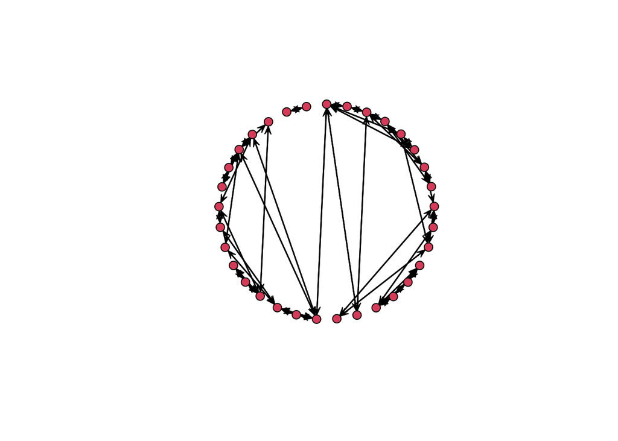

```r
# Now, let's compare two different plot layouts.

# Here is a circle.
gplot( Moreno, mode = "circle" )
```

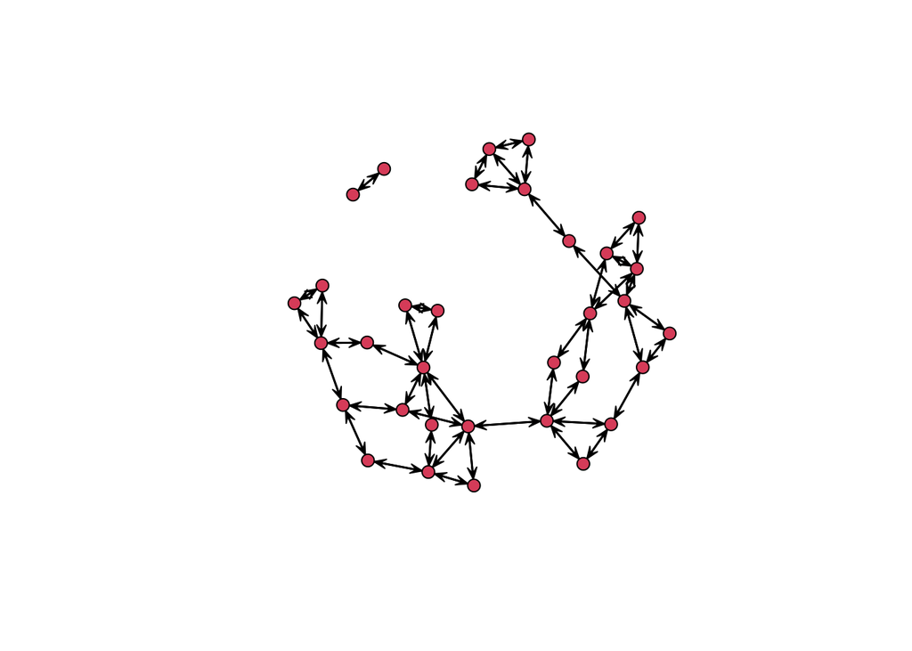

```r
# Here is a separate layout.
gplot( Moreno, mode = "fruchtermanreingold" )
```

Think back to the aesthetic elements we discussed above. How do these two plots differ in how well they convey the **same** information? Which one is better? Why is it better?

To think about these questions, let’s plot the two layouts together. To do this we will use the `par()` function. This allows us to partition the plotting region.

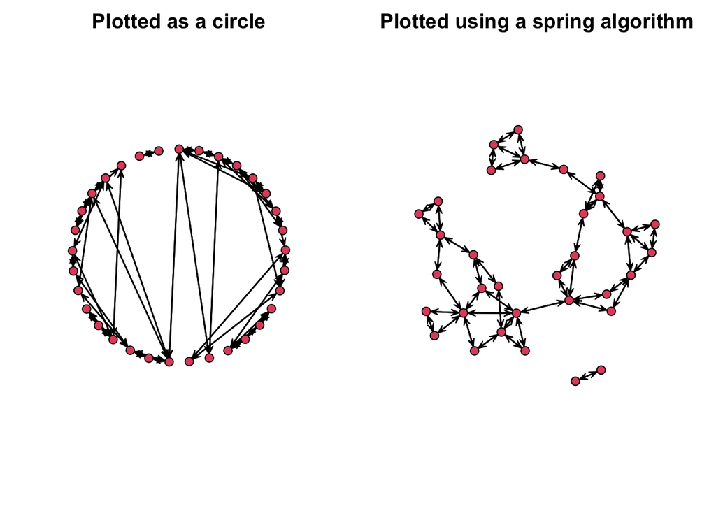

```r
# First, we define the plot layout window.
op <- par(
  mar = rep( 2, 4 ), # set the margins
  mfrow = c( 1, 2 )  # set the dimensions
  )

# plot the circle layout (add the main() argument for a title)
gplot( Moreno, mode = "circle", main = "Plotted as a circle" )

# plot the Fruchterman Reingold layout
gplot( Moreno, mode = "fruchtermanreingold", main = "Plotted using a spring algorithm" )
```

Again, think about our questions: How do these two plots differ in how well they convey the **same** information? Which one is better? Why is it better?

If we add information about gender, we can see a bit more that is revealed by the spring algorithm.

To do so, we use the `vertex.col=` argument with the vertex attribute *gender*. To do so, we need to access the vertex attribute. We can do this with:  
+ the `get.vertex.attribute()` function in the `sna` package. Use `library( sna )` and specify the attribute we want, like `get.vertex.attribute( Moreno, "gender" )`

- or use the shorthand for this with `network object %v% atttribute`, like `Moreno %v% "gender"`

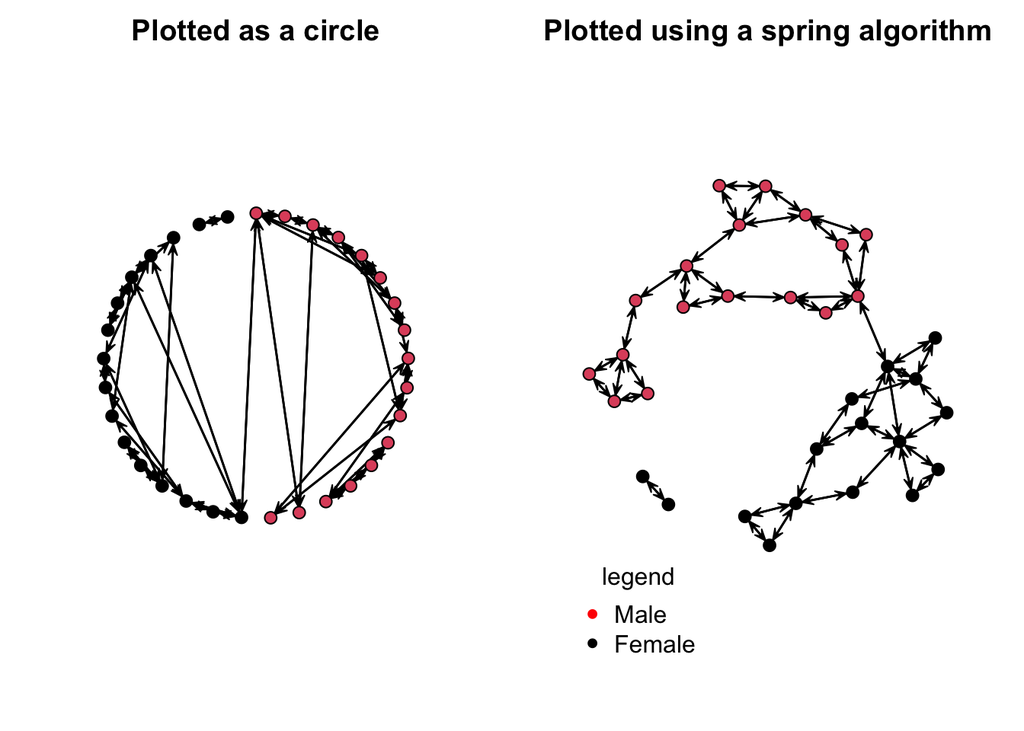

```r
op <- par( mar = rep( 2, 4 ), mfrow = c( 1, 2 ) )

gplot( Moreno,
      mode = "circle",
      main = "Plotted as a circle",
      vertex.col = get.vertex.attribute( Moreno, "gender" ) # use the vertex attribute.
      )

gplot( Moreno,
       mode = "fruchtermanreingold",
       main = "Plotted using a spring algorithm",
       vertex.col = Moreno %v% "gender" # note the difference here compared to above.
       )

# let's add a legend to the plot
legend(
  "bottomleft",
  legend = c( "Male","Female" ),
  col = c( "red","black" ),
  title = "legend",
  pt.cex = 0.75,
  bty = "n",
  pch = 19
  )
```

What is the primary story that the plot tells? Does a particular layout help us see that better?

Ok, that was a lot. Let’s work our way back through the mechanics of building a plot to better get a sense of what we are doing.

### **Working with the `gplot()` function**

Let’s take a look at some of the visualization capabilities of `gplot()`. Let’s start by looking at the function’s help page: `?gplot`.

To see the various functionality of the function, let’s work with the example of an undirected network from [Tutorial 3 - Introduction to Networks in R](https://watts-college.github.io/crj-507-spring-2024/tutorials/tutorial-03-network-data.html).

```r
# define the path where the data are
url <- "https://raw.githubusercontent.com/jacobtnyoung/sna-textbook/main/data/data-undirected-example.csv"

# define the object
mat.u <- as.matrix(
  read.csv(
    url,
    as.is = TRUE,
    header = TRUE,
    row.names = 1
    )
  )

# now, create the network
net.u <- network(
  mat.u,
  directed = FALSE
)

# take a look at the network
summary( net.u )
```

```
## Network attributes:
##   vertices = 5
##   directed = FALSE
##   hyper = FALSE
##   loops = FALSE
##   multiple = FALSE
##   bipartite = FALSE
##  total edges = 5
##    missing edges = 0
##    non-missing edges = 5
##  density = 0.5
##
## Vertex attributes:
##   vertex.names:
##    character valued attribute
##    5 valid vertex names
##
## No edge attributes
##
## Network adjacency matrix:
##      Jen Tom Bob Leaf Jim
## Jen    0   1   0    0   0
## Tom    1   0   1    0   0
## Bob    0   1   0    1   1
## Leaf   0   0   1    0   1
## Jim    0   0   1    1   0
```

```r
#NOTE: we could have wrapped all of this into two statements
net.u <- as.network(
  as.matrix(
    read.csv(
      "https://raw.githubusercontent.com/jacobtnyoung/sna-textbook/main/data/data-undirected-example.csv",
      as.is = TRUE,
      header = TRUE,
      row.names = 1
      )
    ),
  directed = FALSE
  )

summary( net.u )
```

```
## Network attributes:
##   vertices = 5
##   directed = FALSE
##   hyper = FALSE
##   loops = FALSE
##   multiple = FALSE
##   bipartite = FALSE
##  total edges = 5
##    missing edges = 0
##    non-missing edges = 5
##  density = 0.5
##
## Vertex attributes:
##   vertex.names:
##    character valued attribute
##    5 valid vertex names
##
## No edge attributes
##
## Network adjacency matrix:
##      Jen Tom Bob Leaf Jim
## Jen    0   1   0    0   0
## Tom    1   0   1    0   0
## Bob    0   1   0    1   1
## Leaf   0   0   1    0   1
## Jim    0   0   1    1   0
```

Now that we have the object built, we can plot it.

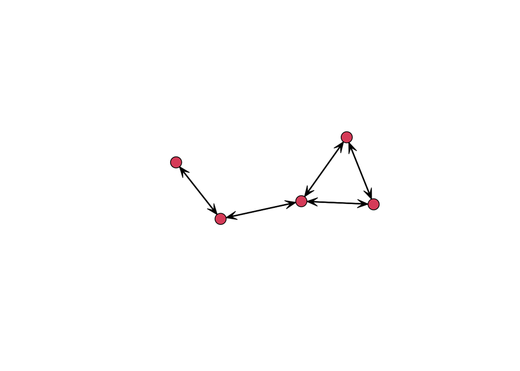

```r
gplot( net.u )
```

Hold on, this plot shows arrows. But this network is undirected. What gives?

That is because `gplot()` assumes a directed network. We can see this in the help menu, `?gplot`, where is shows that for the type of network, the `gmode=` argument defaults to a directed graph. To fix this we can either:

- manually turn off the display of arrows using the `usearrows=` argument, `gplot( net.u, usearrows = FALSE )`
- or indicate that the object to be plotted is a undirected graph or graph, `gplot( net.u, gmode = "graph" )`

The `gplot()` function has a number of arguments that can be used to work try and better display the information contained in the network.

For example, we can add labels to the vertices using the `network.vertex.names()` function.

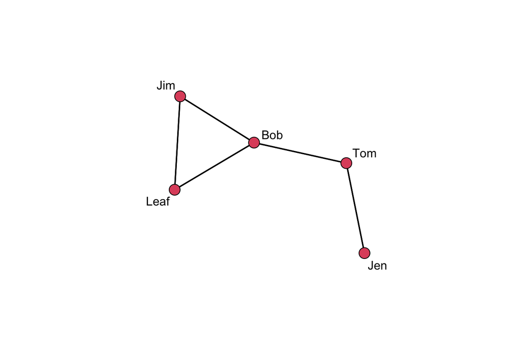

```r
gplot(
  net.u,
  gmode = "graph",
  label = network.vertex.names( net.u )
  )
```

Alternatively, we could add in a string of names for the label:

- `gplot( net.u, gmode = "graph", label = c( "Jen", "Tom", "Bob", "Leaf", "Jim" ) )`

Or we could read them in as an object:

- `names <- c( "Jen", "Tom", "Bob", "Leaf", "Jim" )`
- add to the plot using `gplot( net.u, gmode = "graph", label = names )`

A great feature of R is that we can tune the graphing parameters. Here are several examples:

- Labels:
  - Add boxes around the labels, `boxed.labels = TRUE`
  - Change label size using `label.cex`, such as `label.cex = 1.5`
  - Color the labels using `label.col=`, such as: `label.col = "blue"`
- Colors:
  - different colored names, combine `label.col=` with the `c()` function. Such as: `label.col = c( "red", "blue", "green", "orange", "grey" )`
  - different colored nodes, `vertex.col=` argument. Such as: `vertex.col=c("red","blue","green","orange","grey")`
  - different colored edges, using `edge.col=`, such as: `edge.col=c("red","blue","green","orange","grey")`

There is a LOT of functionality to the `gplot()` function. See the arguements in the help file: `?gplot`. I would encourage you to take some time to look through it and play around with the various features.

### **Adjusting Plot Layout**

When a layout is generated, the results can be saved for later reuse using the `coord=` argument.

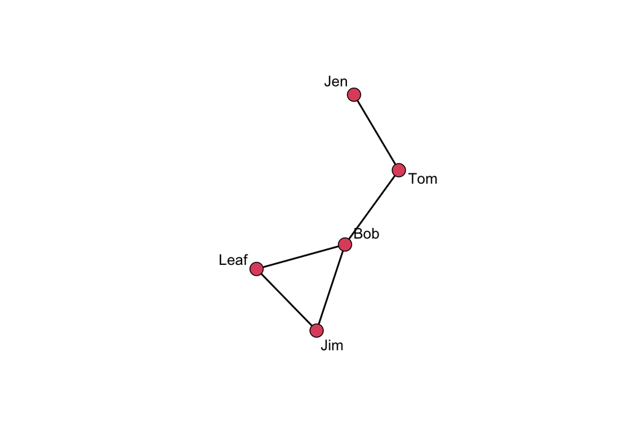

```r
# Set the seed for the random number generator
# so we can always get the same plot layout.
set.seed( 507 )

# Define an object that will be the coordinates we want to use.
coords <- gplot(
  net.u,
  gmode = "graph",
  label = network.vertex.names( net.u )
  )
```

```r
# Show the vertex coordinates.
coords
```

```
##             x        y
## [1,] 3.240723 6.485256
## [2,] 4.008480 5.193206
## [3,] 3.087186 3.921695
## [4,] 1.572750 3.503118
## [5,] 2.600828 2.449065
```

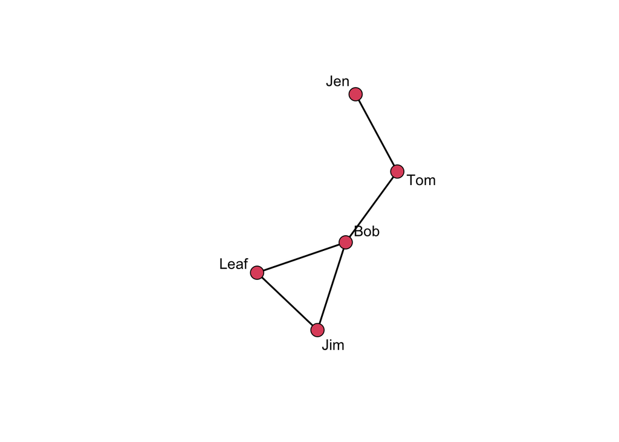

```r
# Saved layouts can be used via the coord= argument:
gplot(
  net.u,
  gmode = "graph",
  label = network.vertex.names( net.u ),
  coord = coords
  )
```

Cool but, *why do this?* The placement of the nodes shift when we call the `gplot()` function just due to the operation of the algorithm. Controlling where nodes are plotted in the 2-dimensional space is useful if we want to show different aspects of the plot. Note that we can have different layouts of the nodes. If we like a particular one, we can save the coordinates.

*But*, suppose the default settings are insufficient and we want to make a few small changes. The `interactive=` argument allows for tweaking.

```r
# First, set up the coordinates you want.
coords <- gplot(
  net.u,
  gmode = "graph",
  label = network.vertex.names( net.u ),
  coord = coords,
  interactive=TRUE
  )
```

When this renders on your system, move a few of the nodes around. Then, after you close the window it will save the coordinates.

```r
# Then, use these in the plot.
gplot(
  net.u,
  coord = coords,
  gmode = "graph",
  label=network.vertex.names( net.u )
  )
```